# Compliance Analytics Open Payments Case

Michael Garcia

May 28, 2019

## Data Preparation

Split the string into columns

```r
#within(cmspayments, FOO<-data.frame(do.call('rbind', strsplit(as.character(cmspayments$Physician_Specialty), '|', fixed=TRUE))))
physplit <- data.frame(do.call('rbind', strsplit(as.character(cmspayments$Physician_Specialty),'|',fixed=TRUE)))
```

```
number of columns of result is not a multiple of vector length (arg 3)
```

```r
colnames(physplit) <- c("PhysSpcOne","PhysSpcTwo","PhysSpcThree")
cmspayments <- cbind(cmspayments,physplit)
```

### Top Companies Prep

Bring top companies into dataframe.

```r
#names(cmspayments)
#Companies is "Submitting_Applicable_Manufacturer_or_Applicable_GPO_Name"
toppayor <- aggregate(Total_Amount_of_Payment_USDollars ~ Submitting_Applicable_Manufacturer_or_Applicable_GPO_Name

                      ,cmspayments,FUN = sum)
colnames(toppayor) <- c("Company","TotalPayment")
toppayor <- head(toppayor[order(toppayor$TotalPayment, decreasing= TRUE),], n = 10)
```

### Simplify the data manipulation

Using RSQLite, use SQL to simplify data manipulation.

Using the top companies dataframe, write to table.

```r
rsqlcon <- dbConnect(RSQLite::SQLite(), ":memory:")

dbWriteTable(conn = rsqlcon
             ,"cmspaytable"
             ,cmspayments
             ,overwrite = TRUE)

topCompany <- RSQLite::dbGetQuery(conn = rsqlcon
                                ,"select Submitting_Applicable_Manufacturer_or_Applicable_GPO_Name as Company
                                        ,sum(Total_Amount_of_Payment_USDollars) as TotalPayments
                                  from cmspaytable
                                  group by 1
                                  order by 2 desc
                                  limit 10"
                                  )
##has top company by revenue
dbWriteTable(conn = rsqlcon
             ,"topcompanytable"
             ,topCompany
             ,overwrite = TRUE)
print(topCompany)
```

| Company | TotalPayments |
| --- | --- |
| DePuy Synthes Sales Inc. | 14038825 |
| Pfizer Inc. | 9591735 |
| MAKO Surgical Corp. | 5359142 |
| Janssen Pharmaceuticals, Inc | 5324497 |
| Allergan Inc. | 4961079 |
| A-dec, Inc. | 3763863 |
| AstraZeneca Pharmaceuticals LP | 3246310 |
| Lanx, Inc. | 3166361 |
| Intuitive Surgical, Inc. | 2988850 |
| AbbVie, Inc. | 2966148 |

Create a dataset with company, payment specialty, and total payments. Group by the attributes and sum the measures. Then get the top companies with specialty only if they exist in the top 10 companies data frame.

```r
topspecialty <- RSQLite::dbGetQuery(conn = rsqlcon
                    , "select c.Submitting_Applicable_Manufacturer_or_Applicable_GPO_Name as Company
                             ,c.Physician_Specialty
                             ,c.PhysSpcOne
                             ,c.PhysSpcTwo
                             ,c.PhysSpcThree
                             ,sum(c.Total_Amount_of_Payment_USDollars) as TotalPayments
                       from cmspaytable as c inner join (select distinct Company
                                          from topcompanytable
                                          order by topcompanytable.TotalPayments desc
                                          limit 5
                                          ) as tt on c.Submitting_Applicable_Manufacturer_or_Applicable_GPO_Name
                                                   = tt.Company
                       group by 1,2
                       order by 3 desc,2,1
                    ")


print(topspecialty)
```

| Company | Physician_Specialty | PhysSpcOne | PhysSpcTwo | PhysSpcThree | TotalPayments |
| --- | --- | --- | --- | --- | --- |
| Janssen Pharmaceuticals, Inc | Technologists, Technicians & Other Technical Service Providers\|Specialist/Technologist, Other\|Nephrology | Technologists, Technicians & Other Technical Service Providers | Specialist/Technologist, Other | Nephrology | 38.31 |
| Allergan Inc. | Technologists, Technicians & Other Technical Service Providers\|Technician, Pathology\|Phlebotomy | Technologists, Technicians & Other Technical Service Providers | Technician, Pathology | Phlebotomy | 120.46 |
| Allergan Inc. | Suppliers\|Durable Medical Equipment & Medical Supplies\|Customized Equipment | Suppliers | Durable Medical Equipment & Medical Supplies | Customized Equipment | 56.38 |
| Allergan Inc. | Suppliers\|Eyewear Supplier (Equipment, not the service) | Suppliers | Eyewear Supplier (Equipment, not the service) | Suppliers | 295.55 |
| Allergan Inc. | Suppliers\|Prosthetic/Orthotic Supplier | Suppliers | Prosthetic/Orthotic Supplier | Suppliers | 124.77 |
| Allergan Inc. | Student, Health Care\|Student in an Organized Health Care Education/Training Program | Student, Health Care | Student in an Organized Health Care Education/Training Program | Student, Health Care | 15113.74 |
| DePuy Synthes Sales Inc. | Student, Health Care\|Student in an Organized Health Care Education/Training Program | Student, Health Care | Student in an Organized Health Care Education/Training Program | Student, Health Care | 1843.53 |
| Janssen Pharmaceuticals, Inc | Student, Health Care\|Student in an Organized Health Care Education/Training Program | Student, Health Care | Student in an Organized Health Care Education/Training Program | Student, Health Care | 4606.62 |
| Pfizer Inc. | Respiratory, Developmental, Rehabilitative and Restorative Service Providers\|Orthotist | Respiratory, Developmental, Rehabilitative and Restorative Service Providers | Orthotist | Respiratory, Developmental, Rehabilitative and Restorative Service Providers | 10.02 |
| Allergan Inc. | Respiratory, Developmental, Rehabilitative and Restorative Service Providers\|Physical Therapist | Respiratory, Developmental, Rehabilitative and Restorative Service Providers | Physical Therapist | Respiratory, Developmental, Rehabilitative and Restorative Service Providers | 126.00 |

[output cut: 487 more lines]

## Visualize

1. Top 10 companies barchart
2. Top 5 companies

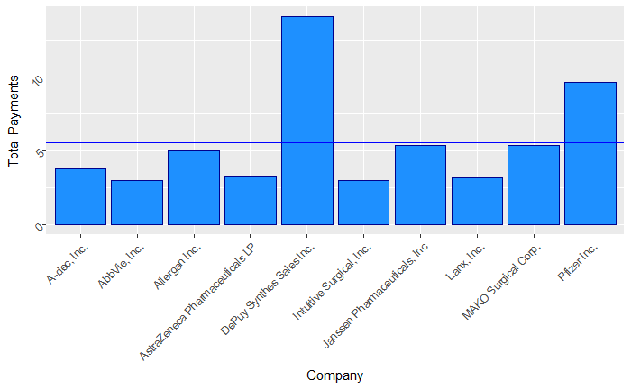

```r
#plot_ly(x = c(topCompany$Company)
#       ,y = c(topCompany$TotalPayments)
#       ,type = "bar")
#par(mfrow - c(2,2))
g <- ggplot(topCompany,aes(Company,TotalPayments/1000000))
g+geom_bar(stat = "identity"
           ,colour = "dark blue"
           ,fill = "dodger blue") +theme(axis.text.x = element_text(angle=45
                                                                ,hjust = 1)
                                     ,axis.text.y = element_text(angle = 45)
                                     )+ labs(y = "Total Payments")+geom_line()+
                geom_hline(yintercept = mean(topCompany$TotalPayments/1000000), color="blue")
```

### Top Companies and Specialty Treemap

The treemap represents the top 5 companies and specialties invested. Depuy and Mako invest in Orthopaedic Surgery. Jansen invests in Internal Medicine. Pfizer and Allergan did not contain quality data to determine their largest specialties invested in. Based on the treemap and not considering data that is not available: it can be seen that the top therapeutic areas are different amongst the competitors and may contribute to maintaining an advantage in the respective therapeutic areas. Further look into annual trends may reveal any changes that may suggest withdrawal or engagement in other areas

```r
### use ping to produce image and control size.
specialtytree <- file.path(getwd(),paste("specialtytreemap",".png",sep = ""))
png(filename = specialtytree,
    width = 1000, height = 850, units = "px", pointsize = 12,
    bg = "white",  res = NA,## ...,
    ##type = c("cairo", "cairo-png", "Xlib", "quartz"),
    antialias = c("default")
)


## use PhysSpcTwo for more specific view
treemap::treemap(dtf = topspecialty, index = c("Company","PhysSpcTwo")
                 ,type = "index"
                 , fontsize.labels=c(12,10,10)
                 ,vSize = "TotalPayments"
                 ,vColor = "Physician_Specialty"
                 ,command.line.output = FALSE
                 #,fontface.labels = "bold"
                 ,palette = "Set1"
                 ,fun.aggregate = "sum"
                 , align.labels=list(
                                      c("center", "center"),
                                      c("center", "bottom")
                                      )
                  )
dev.off()
```

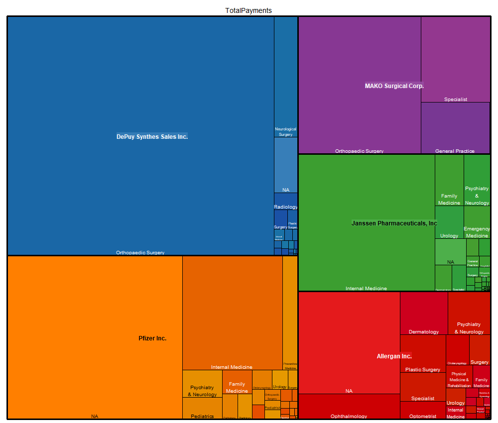

Specialty Tree Map

### Physician Group Analysis

```r
phys <- cmspayments[c("Physician_Primary_Type"
                      ,"Total_Amount_of_Payment_USDollars"
                      ,"Physician_Profile_ID","Covered_Recipient_Type")]

physmean <- aggregate(Total_Amount_of_Payment_USDollars~Covered_Recipient_Type+Physician_Primary_Type
                     ,data = phys
                     ,FUN = "mean"
                     )
#physmax <- aggregate(Total_Amount_of_Payment_USDollars~phys$Covered_Recipient_Type+phys$Physician_Primary_Type
#                     ,data = phys
#                     ,FUN = "max"
#                     )

physidcount <- aggregate(Total_Amount_of_Payment_USDollars~Covered_Recipient_Type+Physician_Primary_Type
                     ,data = phys
                     ,FUN = "length"
                     )

physummary <- merge(x=physmean,y=physidcount, by = c("Physician_Primary_Type"
                                               ,"Covered_Recipient_Type")
                    )
colnames(physummary) <- c("Physician_Primary_Type","Covered_Recipient_Type"
                          ,"AveragePayment","NumberofPayments")
```